# CTA 'L' Train Ridership Analysis

### by Carter Wooton

This notebook analyzes ridership data for the Chicago Transit Authority (CTA) 'L' train system. It covers data loading, preprocessing, merging with station information, calculating growth rates, and creating interactive maps to visualize station-level changes over time.

```python
# Import necessary libraries for data analysis and visualization
import numpy as np
import pandas as pd
import matplotlib.pyplot as plt
```

```python
# Load CTA 'L' ridership data
# url: https://data.cityofchicago.org/Transportation/CTA-Ridership-L-Station-Entries-Daily-Totals/5neh-572f/about_data
l_ridership_path = "data/CTA_-_Ridership_-_'L'_Station_Entries_-_Daily_Totals_20250824.csv"
l_ridership = pd.read_csv(l_ridership_path, low_memory=False)

# Load CTA station information
# url: https://data.cityofchicago.org/Transportation/CTA-System-Information-List-of-L-Stops/8pix-ypme/about_data
stations_path = "data/CTA_-_System_Information_-_List_of_'L'_Stops_20250824.csv"
stations = pd.read_csv(stations_path, low_memory=False)
```

## Data Loading and Initial Preprocessing

Load ridership and station data, filter invalid stations, convert data types, and extract line information from station descriptions.

```python
# Data preprocessing: filter out invalid stations, convert rides to numeric, select station columns, extract lines

# Filter out stations with no ridership data: Homan and Washington/State
# Note: Washington/State is actually Lake/State on the Red Line; Homan is Kedzie/Homan/Forest-Park
l_ridership = l_ridership[~l_ridership["stationname"].isin(["Homan", "Washington/State"])]

# Convert 'rides' column to numeric by removing commas (handles string formatting)
l_ridership['rides'] = pd.to_numeric(l_ridership['rides'].str.replace(',', ''))

# Select relevant columns from stations DataFrame for unique station identification
stations = stations[['STATION_NAME', 'STATION_DESCRIPTIVE_NAME','MAP_ID', 'Location']]

# Import regex module for pattern matching
import re

# Function to extract train line colors from station descriptive names using regex
def extract_lines(desc):
    # Find all occurrences of line colors (e.g., Pink, Orange, etc.) in the description
    colors = re.findall(r'\b(Pink|Orange|Green|Blue|Red|Purple|Yellow|Brown)\b', desc)
    # Return comma-separated string of colors if found, else None
    return ', '.join(colors) if colors else None

# Apply the function to create a new 'Line' column indicating which lines serve each station
stations['Line'] = stations['STATION_DESCRIPTIVE_NAME'].apply(extract_lines)
```

```python
# Merge ridership data with station data to include station details
cta_l_ridership_stations = l_ridership.merge(stations, left_on='station_id', right_on='MAP_ID', how='left')

# Identify rows where merge failed (no MAP_ID)
no_map_id = cta_l_ridership_stations[cta_l_ridership_stations["MAP_ID"].isna()]

# Identify dead stations that were combined into Washington/Wabash
dead_stations = cta_l_ridership_stations[cta_l_ridership_stations['stationname'].isin(['Randolph/Wabash', 'Madison/Wabash'])]
```

### For the stations Randolph/Wabash and Madison/Wabash, I will combine these into the new Washington/Wabash station by thaking their average daily rides by day

```python
# Create new rows for the combined Washington/Wabash station by averaging daily rides from dead stations
new_rows = pd.DataFrame()
new_location = cta_l_ridership_stations[cta_l_ridership_stations["stationname"] == "Washington/Wabash"]["Location"].values[0]
new_map_id = cta_l_ridership_stations[cta_l_ridership_stations["stationname"] == "Washington/Wabash"]["MAP_ID"].values[0]
new_station_id = cta_l_ridership_stations[cta_l_ridership_stations["stationname"] == "Washington/Wabash"]["station_id"].values[0]
for date in dead_stations['date'].unique():
    subset = dead_stations[dead_stations['date'] == date]
    avg_rides = subset['rides'].mean()
    new_row = {
        'station_id': new_station_id,
        'stationname': 'Washington/Wabash',
        'date': date,
        'daytype': subset['daytype'].values[0],
        'rides': avg_rides,
        'STATION_NAME': 'Washington/Wabash',
        'STATION_DESCRIPTIVE_NAME': 'Washington/Wabash (combined from Randolph/Wabash and Madison/Wabash)',
        'MAP_ID': new_map_id,
        'Location': new_location
    }
    new_rows = pd.concat([new_rows, pd.DataFrame([new_row])], ignore_index=True)
```

```python
# Append new combined rows to the dataset and remove the old dead station rows
cta_l_ridership_stations = pd.concat([cta_l_ridership_stations, new_rows], ignore_index=True)
cta_l_ridership_stations = cta_l_ridership_stations[~cta_l_ridership_stations["stationname"].isin(["Randolph/Wabash", "Madison/Wabash"])]

# Update the Line information for Washington/Wabash station
cta_l_ridership_stations.loc[cta_l_ridership_stations['stationname'] == 'Washington/Wabash', 'Line'] = 'Brown, Green, Orange, Purple, Pink'
```

```python
# Final data cleaning and preparation

# Remove duplicate rows from the merge
cta_l_ridership_stations = cta_l_ridership_stations.drop_duplicates().reset_index(drop=True)

# Remove rows with duplicate dates for the same station
cta_l_ridership_stations = cta_l_ridership_stations.drop_duplicates(subset=['station_id', 'date']).reset_index(drop=True)

# Convert 'date' to datetime if not already
cta_l_ridership_stations['date'] = pd.to_datetime(cta_l_ridership_stations['date'])

# Sort by station_id and date
cta_l_ridership_stations = cta_l_ridership_stations.sort_values(by=['station_id', 'date']).reset_index(drop=True)

# Exclude 2025 from the analysis because the data is incomplete
cta_l_ridership_stations = cta_l_ridership_stations[cta_l_ridership_stations['date'].dt.year != 2025]

# Create a new column 'day_of_week' with the day name
cta_l_ridership_stations['day_of_week'] = cta_l_ridership_stations['date'].dt.day_name()
```

## Ridership Analysis

Calculate yearly averages by station and day of week, overall averages by year, and visualize weekday ridership percentages over time.

```python
# Calculate yearly averages by station and day of week
# Group data by station, year, and day of week, then compute mean rides
grouped = cta_l_ridership_stations.groupby(['stationname', cta_l_ridership_stations['date'].dt.year, 'day_of_week'])['rides'].mean().reset_index()

# Pivot the grouped data to create columns for each day of the week
yearly_avg_by_station = grouped.pivot(index=['stationname', 'date'], columns='day_of_week', values='rides').reset_index()

# Rename columns for clarity (assuming standard days; adjust if needed)
yearly_avg_by_station = yearly_avg_by_station.rename(columns={
    'Monday': 'avg_monday',
    'Tuesday': 'avg_tuesday',
    'Wednesday': 'avg_wednesday',
    'Thursday': 'avg_thursday',
    'Friday': 'avg_friday',
    'Saturday': 'avg_saturday',
    'Sunday': 'avg_sunday'
})

# Merge with the main dataset to retain MAP_ID and Location for mapping
yearly_avg_by_station = yearly_avg_by_station.merge(cta_l_ridership_stations[['stationname', 'MAP_ID', 'Location', 'Line']].drop_duplicates(), left_on='stationname', right_on='stationname', how='left')
```

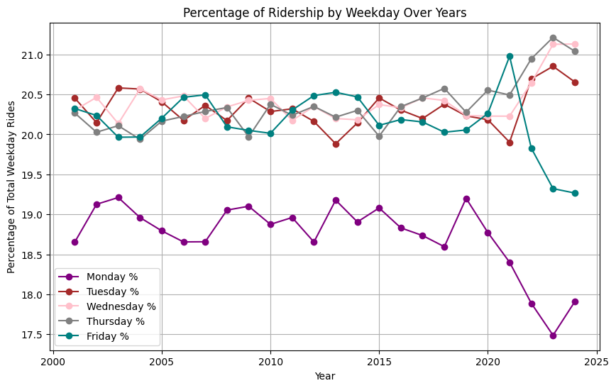

```python
# Calculate overall averages by year and day of week across all stations
grouped_day = cta_l_ridership_stations.groupby([cta_l_ridership_stations['date'].dt.year, 'day_of_week'])['rides'].mean().reset_index()

# Pivot to create columns for each day of the week
overall_avg_by_year_day = grouped_day.pivot(index='date', columns='day_of_week', values='rides').reset_index()

# Rename columns for clarity
overall_avg_by_year_day = overall_avg_by_year_day.rename(columns={
    'Monday': 'avg_monday',
    'Tuesday': 'avg_tuesday',
    'Wednesday': 'avg_wednesday',
    'Thursday': 'avg_thursday',
    'Friday': 'avg_friday',
    'Saturday': 'avg_saturday',
    'Sunday': 'avg_sunday'
})

# Calculate total weekday rides (Mon-Fri) for each year
weekday_cols = ['avg_monday', 'avg_tuesday', 'avg_wednesday', 'avg_thursday', 'avg_friday']
overall_avg_by_year_day['total_weekday'] = overall_avg_by_year_day[weekday_cols].sum(axis=1)

# Calculate percentage for each weekday relative to total weekday rides
for col in weekday_cols:
    overall_avg_by_year_day[f'{col}_pct'] = (overall_avg_by_year_day[col] / overall_avg_by_year_day['total_weekday']) * 100

# Plot the percentages for each weekday over time
plt.figure(figsize=(10, 6))
plt.plot(overall_avg_by_year_day['date'], overall_avg_by_year_day['avg_monday_pct'], label='Monday %', marker='o', color='purple')
plt.plot(overall_avg_by_year_day['date'], overall_avg_by_year_day['avg_tuesday_pct'], label='Tuesday %', marker='o', color='brown')
plt.plot(overall_avg_by_year_day['date'], overall_avg_by_year_day['avg_wednesday_pct'], label='Wednesday %', marker='o', color='pink')
plt.plot(overall_avg_by_year_day['date'], overall_avg_by_year_day['avg_thursday_pct'], label='Thursday %', marker='o', color='gray')
plt.plot(overall_avg_by_year_day['date'], overall_avg_by_year_day['avg_friday_pct'], label='Friday %', marker='o', color='teal')
plt.xlabel('Year')
plt.ylabel('Percentage of Total Weekday Rides')
plt.title('Percentage of Ridership by Weekday Over Years')
plt.legend()
plt.grid(True)
plt.show()
plt.savefig('graphics/weekday_ridership_percentage_by_year.png')
```

```python
# Calculate overall average ridership per station for all years
yearly_avg_by_station['overall_avg'] = yearly_avg_by_station[['avg_monday', 'avg_tuesday', 'avg_wednesday', 'avg_thursday', 'avg_friday', 'avg_saturday', 'avg_sunday']].mean(axis=1)
```

## Growth Calculations

Compute Compound Annual Growth Rate (CAGR) for ridership at each station over different time periods (2001-2019 and 2021-2024) to identify top gainers and losers.

```python
# Calculate CAGR for 2021-2024 period
# Filter data for years 2021 to 2024
data_21_24 = yearly_avg_by_station[(yearly_avg_by_station['date'] >= 2021) & (yearly_avg_by_station['date'] <= 2024)]

# Function to compute CAGR: (final/initial)^(1/n) - 1, where n is number of years
def compute_cagr_21_24(group):
    if len(group) < 2:
        return pd.Series({'cagr': np.nan})
    initial_series = group[group['date'] == 2021]['overall_avg']
    final_series = group[group['date'] == 2024]['overall_avg']
    if initial_series.empty or final_series.empty:
        return pd.Series({'cagr': np.nan})
    initial = initial_series.values[0]
    final = final_series.values[0]
    n = 2024 - 2021  # 3 years
    if initial > 0:
        cagr = (final / initial)**(1/n) - 1
    else:
        cagr = np.nan
    return pd.Series({'cagr': cagr})

# Apply CAGR calculation to each station group
growth_df_21_24 = data_21_24.groupby('stationname').apply(compute_cagr_21_24).reset_index()

# Convert CAGR to percentage
growth_df_21_24['growth_percentage'] = growth_df_21_24['cagr'] * 100
growth_df_21_24 = growth_df_21_24.drop(columns=['cagr'])

# Round to 2 decimal places and sort descending
growth_df_21_24['growth_percentage'] = growth_df_21_24['growth_percentage'].round(2)
growth_df_21_24 = growth_df_21_24.dropna(subset=['growth_percentage'])
growth_df_21_24 = growth_df_21_24.sort_values(by='growth_percentage', ascending=False)

# Remove stations with extreme negative growth (likely data issues)
growth_df_21_24 = growth_df_21_24[growth_df_21_24['growth_percentage'] > -100]
```

## Interactive Maps

Create Folium maps to visualize station growth rates geographically, with clustering, legends, and interactive features for both 2021-2024 and 2001-2019 periods.

```python
# Create interactive Folium map for 2021-2024 growth rates
# Import required libraries for mapping
import folium
import pandas as pd
from folium.plugins import MarkerCluster
from folium.utilities import JsCode
import matplotlib.colors as mcolors

# Prepare data: merge growth with station locations and lines
all_stations_growth = growth_df_21_24.merge(yearly_avg_by_station[['stationname', 'Location', 'Line']].drop_duplicates(), on='stationname', how='left')

# Filter out invalid growth rates
all_stations_growth = all_stations_growth[all_stations_growth['growth_percentage'] > -100]

# Extract latitude and longitude from location strings
all_stations_growth['lat'] = all_stations_growth['Location'].str.extract(r'\(([^,]+),')[0].astype(float)
all_stations_growth['lon'] = all_stations_growth['Location'].str.extract(r', ([^)]+)\)')[0].astype(float)

# Calculate mean growth for display
mean_growth_21_24 = all_stations_growth['growth_percentage'].mean()

# Initialize Folium map centered on Chicago
m = folium.Map(location=[41.8781, -87.6298], zoom_start=10)

# Custom icon function for cluster averaging colors
icon_create_function = r"""
function(cluster) {
    // Helper functions to convert between hex and RGB
    function hexToRgb(hex) {
        let result = /^#?([a-f\d]{2})([a-f\d]{2})([a-f\d]{2})$/i.exec(hex);
        return result ? {
            r: parseInt(result[1], 16),
            g: parseInt(result[2], 16),
            b: parseInt(result[3], 16)
        } : null;
    }
    function componentToHex(c) {
        let hex = c.toString(16);
        return hex.length == 1 ? "0" + hex : hex;
    }
    function rgbToHex(r, g, b) {
        return "#" + componentToHex(r) + componentToHex(g) + componentToHex(b);
    }

    let childMarkers = cluster.getAllChildMarkers();
    let total_r = 0, total_g = 0, total_b = 0;

    // Sum the RGB values of all markers in the cluster
    childMarkers.forEach(function(marker) {
        let markerColor = marker.options.fillColor;
        let rgb = hexToRgb(markerColor);
        if (rgb) {
            total_r += rgb.r;
            total_g += rgb.g;
            total_b += rgb.b;
        }
    });

    // Calculate the average RGB
    let count = childMarkers.length;
    let avg_r = Math.round(total_r / count);
    let avg_g = Math.round(total_g / count);
    let avg_b = Math.round(total_b / count);

    let avg_hex_color = rgbToHex(avg_r, avg_g, avg_b);

    let childCount = cluster.getChildCount();
    let c = ' marker-cluster-';
    if (childCount < 10) {
        c += 'small';
    } else if (childCount < 100) {
        c += 'medium';
    } else {
        c += 'large';
    }

    // Create and return the custom icon
    return new L.DivIcon({
        html: `<div style="background-color: ${avg_hex_color};"><span>${childCount}</span></div>`,
        className: 'marker-cluster' + c,
        iconSize: new L.Point(40, 40)
    });
}
"""

# Add marker cluster with custom icon
marker_cluster = MarkerCluster(
    options={
        'iconCreateFunction': JsCode(icon_create_function)
    }
).add_to(m)

# Normalize growth for color mapping (red to green)
min_growth = all_stations_growth['growth_percentage'].min()
max_growth = all_stations_growth['growth_percentage'].max()
norm = mcolors.Normalize(vmin=min_growth, vmax=max_growth)
cmap = mcolors.LinearSegmentedColormap.from_list("growth_cmap", ["red", "yellow", "green"])

# Function to map growth to color
def get_color(growth):
    rgba = cmap(norm(growth))
    return mcolors.to_hex(rgba)

# Add circle markers for each station
for idx, row in all_stations_growth.iterrows():
    color = get_color(row['growth_percentage'])
    popup_text = f"""
        <div style="min-width: 150px;">
            <b>{row['stationname']}</b><br>
            Growth: {row['growth_percentage']}%<br>
            Line: {row['Line']}
        </div>
    """
    folium.CircleMarker(
        location=[row['lat'], row['lon']],
        radius=13,
        color=color,
        fill=True,
        fill_color=color,
        fill_opacity=0.7,
        popup=popup_text,
        tooltip=row['stationname']
    ).add_to(marker_cluster)

# Add colorbar legend
colormap = folium.LinearColormap(
    colors=["red", "yellow", "green"],
    vmin=min_growth,
    vmax=max_growth,
    caption="Growth Rate (%) from 2021-2024"
)
colormap.add_to(m)

# Sort stations for legend
sorted_stations = all_stations_growth.sort_values(by='growth_percentage', ascending=False)

# Create interactive legend with sorting buttons
legend_items = []
for idx, row in sorted_stations.iterrows():
    color = get_color(row['growth_percentage'])
    popup_text = f"""
        <b>{row['stationname']}</b><br>
        Growth: {row['growth_percentage']}%<br>
        Line: {row['Line']}
    """
    js_safe_popup_text = popup_text.replace("`", "'")
    onclick_js = (
        f"{m.get_name()}.setView([{row['lat']}, {row['lon']}], 16); "
        f"L.popup().setLatLng([{row['lat']}, {row['lon']}]).setContent(`{js_safe_popup_text}`).openOn({m.get_name()});"
    )
    legend_items.append(
        f'<li class="legend-item" '
        f'data-name="{row["stationname"]}" '
        f'data-percent="{row["growth_percentage"]}" '
        f'onclick="{onclick_js}" style="cursor:pointer; color:{color};">'
        f'{row["stationname"]}: {row["growth_percentage"]:.2f}%</li>'
    )

legend_list = ''.join(legend_items)

# HTML for the legend panel
legend_html = f'''
<div style="position: fixed;
    top: 50px; right: 10px; width: 250px; height: 400px;
    background-color: black; border:2px solid grey; z-index:9999; font-size:12px; overflow-y: auto;">
    <style>
    .legend-item:hover {{
        background-color: rgba(255, 255, 255, 0.2);
        font-weight: bold;
    }}
    .sort-button {{
        background-color: #333; color: white; border: 1px solid grey;
        padding: 2px 6px; margin: 2px; cursor: pointer;
    }}
    .sort-button:hover {{ background-color: #555; }}
    </style>
    <b style="color: white;">All Stations Growth (2021-2024)</b><br>
    <b style="color: white;">Mean Growth: {mean_growth_21_24:.2f}%</b><br>
    <div style="padding: 2px 0;">
        <button class="sort-button" onclick="sortLegend('percent')">Sort by %</button>
        <button class="sort-button" onclick="sortLegend('alpha')">Sort by Name</button>
    </div>
    <ul id="station-legend-list" style="list-style-type: none; padding: 0;">
    {legend_list}
    </ul>
</div>
'''
m.get_root().html.add_child(folium.Element(legend_html))

# JavaScript for sorting the legend
legend_sorter_js = """
<script>
function sortLegend(sortBy) {
    const list = document.getElementById('station-legend-list');
    const items = Array.from(list.getElementsByTagName('li'));

    items.sort(function(a, b) {
        if (sortBy === 'alpha') {
            const nameA = a.getAttribute('data-name').toUpperCase();
            const nameB = b.getAttribute('data-name').toUpperCase();
            return nameA.localeCompare(nameB);
        } else if (sortBy === 'percent') {
            const percentA = parseFloat(a.getAttribute('data-percent'));
            const percentB = parseFloat(b.getAttribute('data-percent'));
            return percentB - percentA;
        }
    });

    list.innerHTML = '';
    items.forEach(function(item) {
        list.appendChild(item);
    });
}
</script>
"""
m.get_root().html.add_child(folium.Element(legend_sorter_js))

# Add reset view button
reset_button_html = '''
<div style="position: fixed;
    bottom: 50px; left: 10px; z-index:9999;">
    <button onclick="{}" style="background-color: white; border: 2px solid grey; padding: 5px 10px; cursor: pointer;">Reset View</button>
</div>
'''.format(f"{m.get_name()}.setView([41.8781, -87.6298], 10);")
m.get_root().html.add_child(folium.Element(reset_button_html))

# Save the map as HTML file
m.save('maps/all_stations_growth_2021_2024_map_sorted.html')
```

```python
# Calculate CAGR for 2001-2019 period
# Filter data for years 2001 to 2019
data = yearly_avg_by_station[(yearly_avg_by_station['date'] >= 2001) & (yearly_avg_by_station['date'] <= 2019)]

# Function to compute CAGR over 18 years
def compute_cagr(group):
    if len(group) < 2:
        return pd.Series({'cagr': np.nan})
    initial_series = group[group['date'] == 2001]['overall_avg']
    final_series = group[group['date'] == 2019]['overall_avg']
    if initial_series.empty or final_series.empty:
        return pd.Series({'cagr': np.nan})
    initial = initial_series.values[0]
    final = final_series.values[0]
    n = 2019 - 2001  # 18 years
    if initial > 0:
        cagr = (final / initial)**(1/n) - 1
    else:
        cagr = np.nan
    return pd.Series({'cagr': cagr})

# Compute CAGR for each station
growth_df = data.groupby('stationname').apply(compute_cagr).reset_index()

# Convert to percentage and clean up
growth_df['growth_percentage'] = growth_df['cagr'] * 100
growth_df = growth_df.drop(columns=['cagr'])
growth_df['growth_percentage'] = growth_df['growth_percentage'].round(2)
growth_df = growth_df.sort_values(by='growth_percentage', ascending=False)
growth_df = growth_df.dropna(subset=['growth_percentage'])
```

```python
# Create interactive Folium map for 2001-2019 growth rates
# Import required libraries for mapping
import folium
import pandas as pd # Assuming you're using pandas for the DataFrame
from folium.plugins import MarkerCluster
from folium.utilities import JsCode # <-- 1. Import JsCode
import matplotlib.colors as mcolors

# Prepare data: merge growth with station locations (include all stations, even with NaN)
all_stations_growth = yearly_avg_by_station[['stationname', 'Location', 'Line']].drop_duplicates().merge(growth_df, on='stationname', how='left')

# Remove stations with NaN growth_percentage
all_stations_growth = all_stations_growth.dropna(subset=['growth_percentage'])

# Extract latitude and longitude from Location
all_stations_growth['lat'] = all_stations_growth['Location'].str.extract(r'\(([^,]+),')[0].astype(float)
all_stations_growth['lon'] = all_stations_growth['Location'].str.extract(r', ([^)]+)\)')[0].astype(float)

# Calculate mean growth for display
mean_growth = all_stations_growth['growth_percentage'].mean()

# Create a Folium map centered on Chicago
m = folium.Map(location=[41.8781, -87.6298], zoom_start=10)

# Custom icon function for cluster averaging colors
icon_create_function = r"""
function(cluster) {
    // Helper functions to convert between hex and RGB
    function hexToRgb(hex) {
        let result = /^#?([a-f\d]{2})([a-f\d]{2})([a-f\d]{2})$/i.exec(hex);
        return result ? {
            r: parseInt(result[1], 16),
            g: parseInt(result[2], 16),
            b: parseInt(result[3], 16)
        } : null;
    }
    function componentToHex(c) {
        let hex = c.toString(16);
        return hex.length == 1 ? "0" + hex : hex;
    }
    function rgbToHex(r, g, b) {
        return "#" + componentToHex(r) + componentToHex(g) + componentToHex(b);
    }

    let childMarkers = cluster.getAllChildMarkers();
    let total_r = 0, total_g = 0, total_b = 0;

    // Sum the RGB values of all markers in the cluster
    childMarkers.forEach(function(marker) {
        let markerColor = marker.options.fillColor;
        let rgb = hexToRgb(markerColor);
        if (rgb) {
            total_r += rgb.r;
            total_g += rgb.g;
            total_b += rgb.b;
        }
    });

    // Calculate the average RGB
    let count = childMarkers.length;
    let avg_r = Math.round(total_r / count);
    let avg_g = Math.round(total_g / count);
    let avg_b = Math.round(total_b / count);

    let avg_hex_color = rgbToHex(avg_r, avg_g, avg_b);

    let childCount = cluster.getChildCount();
    let c = ' marker-cluster-';
    if (childCount < 10) {
        c += 'small';
    } else if (childCount < 100) {
        c += 'medium';
    } else {
        c += 'large';
    }

    // Create and return the custom icon
    return new L.DivIcon({
        html: `<div style="background-color: ${avg_hex_color};"><span>${childCount}</span></div>`,
        className: 'marker-cluster' + c,
        iconSize: new L.Point(40, 40)
    });
}
"""

# Add marker cluster with custom icon
marker_cluster = MarkerCluster(
    options={
        'iconCreateFunction': JsCode(icon_create_function)
    }
).add_to(m)

# Normalize growth_percentage for colormap
min_growth = all_stations_growth['growth_percentage'].min()
max_growth = all_stations_growth['growth_percentage'].max()
norm = mcolors.Normalize(vmin=min_growth, vmax=max_growth)
cmap = mcolors.LinearSegmentedColormap.from_list("growth_cmap", ["red", "yellow", "green"])

# Function to get color from growth_percentage
def get_color(growth):
    rgba = cmap(norm(growth))
    return mcolors.to_hex(rgba)

# Add markers for each station
for idx, row in all_stations_growth.iterrows():
    color = get_color(row['growth_percentage'])
    popup_text = f"""
        <div style="min-width: 150px;">
            <b>{row['stationname']}</b><br>
            Growth: {row['growth_percentage']}%<br>
            Line: {row['Line']}
        </div>
    """
    folium.CircleMarker(
        location=[row['lat'], row['lon']],
        radius=13,
        color=color,
        fill=True,
        fill_color=color,
        fill_opacity=0.7,
        popup=popup_text,
        tooltip=row['stationname']
    ).add_to(marker_cluster)

# Add a linear colormap legend
colormap = folium.LinearColormap(
    colors=["red", "yellow", "green"],
    vmin=min_growth,
    vmax=max_growth,
    caption="Growth Rate (%) from 2001-2019"
)
colormap.add_to(m)

# Sort all_stations_growth by growth_percentage descending for the legend
sorted_stations = all_stations_growth.sort_values(by='growth_percentage', ascending=False)

# Create the legend HTML
legend_items = []
for idx, row in sorted_stations.iterrows():
    color = get_color(row['growth_percentage'])
    popup_text = f"""
        <b>{row['stationname']}</b><br>
        Growth: {row['growth_percentage']}%<br>
        Line: {row['Line']}
    """
    js_safe_popup_text = popup_text.replace("`", "'")
    onclick_js = (
        f"{m.get_name()}.setView([{row['lat']}, {row['lon']}], 16); "
        f"L.popup().setLatLng([{row['lat']}, {row['lon']}]).setContent(`{js_safe_popup_text}`).openOn({m.get_name()});"
    )
    legend_items.append(
        f'<li class="legend-item" '
        f'data-name="{row["stationname"]}" '
        f'data-percent="{row["growth_percentage"]}" '
        f'onclick="{onclick_js}" style="cursor:pointer; color:{color};">'
        f'{row["stationname"]}: {row["growth_percentage"]:.2f}%</li>'
    )

legend_list = ''.join(legend_items)

# HTML for the legend panel
legend_html = f'''
<div style="position: fixed;
    top: 50px; right: 10px; width: 250px; height: 400px;
    background-color: black; border:2px solid grey; z-index:9999; font-size:12px; overflow-y: auto;">
    <style>
    .legend-item:hover {{
        background-color: rgba(255, 255, 255, 0.2);
        font-weight: bold;
    }}
    .sort-button {{
        background-color: #333; color: white; border: 1px solid grey;
        padding: 2px 6px; margin: 2px; cursor: pointer;
    }}
    .sort-button:hover {{ background-color: #555; }}
    </style>
    <b style="color: white;">All Stations Growth (2001-2019)</b><br>
    <b style="color: white;">Mean Growth: {mean_growth:.2f}%</b><br>
    <div style="padding: 2px 0;">
        <button class="sort-button" onclick="sortLegend('percent')">Sort by %</button>
        <button class="sort-button" onclick="sortLegend('alpha')">Sort by Name</button>
    </div>
    <ul id="station-legend-list" style="list-style-type: none; padding: 0;">
    {legend_list}
    </ul>
</div>
'''
m.get_root().html.add_child(folium.Element(legend_html))

# JavaScript for sorting the legend
legend_sorter_js = """
<script>
function sortLegend(sortBy) {
    const list = document.getElementById('station-legend-list');
    const items = Array.from(list.getElementsByTagName('li'));

    items.sort(function(a, b) {
        if (sortBy === 'alpha') {
            const nameA = a.getAttribute('data-name').toUpperCase();
            const nameB = b.getAttribute('data-name').toUpperCase();
            return nameA.localeCompare(nameB);
        } else if (sortBy === 'percent') {
            const percentA = parseFloat(a.getAttribute('data-percent'));
            const percentB = parseFloat(b.getAttribute('data-percent'));
            return percentB - percentA;
        }
    });

    list.innerHTML = '';
    items.forEach(function(item) {
        list.appendChild(item);
    });
}
</script>
"""
m.get_root().html.add_child(folium.Element(legend_sorter_js))

# Add a reset button to reset to original view
reset_button_html = '''
<div style="position: fixed;
    bottom: 50px; left: 10px; z-index:9999;">
    <button onclick="{}" style="background-color: white; border: 2px solid grey; padding: 5px 10px; cursor: pointer;">Reset View</button>
</div>
'''.format(f"{m.get_name()}.setView([41.8781, -87.6298], 10);")
m.get_root().html.add_child(folium.Element(reset_button_html))

# Save the map to an HTML file
m.save('maps/all_stations_growth_2001_2019_map_sorted.html')
```

## Line-by-Line Comparisons

```python
# Define the list of CTA line names for analysis
line_names = ['Red', 'Blue', 'Brown', 'Green', 'Orange', 'Purple', 'Pink', 'Yellow']

# Add a 'year' column to the main dataset for grouping
cta_l_ridership_stations['year'] = cta_l_ridership_stations['date'].dt.year

# Group by station and year to calculate total annual rides per station
yearly_station_sum = (
    cta_l_ridership_stations
    .groupby(['station_id', 'stationname', 'year', 'Line'], as_index=False)['rides']
    .sum()
    .rename(columns={'rides': 'total_rides'})
)
```

```python
# Expand the data to handle stations serving multiple lines
# Create a list to store expanded rows
expanded_rows = []

for _, row in yearly_station_sum.iterrows():
    lines = [line.strip() for line in row['Line'].split(',')]
    for line in lines:
        expanded_rows.append({
            'station_id': row['station_id'],
            'stationname': row['stationname'],
            'year': row['year'],
            'Line': line,
            'total_rides': row['total_rides']
        })

# Create expanded dataframe with one row per station-line combination
expanded_df = pd.DataFrame(expanded_rows)

# Calculate yearly total rides per line
yearly_line_sum = expanded_df.groupby(['Line', 'year', 'stationname'])['total_rides'].sum().reset_index()

# Aggregate to get total rides per line per year
yearly_line_sum = (
    yearly_line_sum
    .groupby(['Line', 'year'])['total_rides']
    .sum()
    .reset_index()
    .pivot(index='Line', columns='year', values='total_rides')
)
yearly_line_sum
```

| year Line | 2001 | 2002 | 2003 | 2004 | 2005 | 2006 | 2007 | 2008 | 2009 | 2010 | ... | 2015 | 2016 | 2017 | 2018 | 2019 | 2020 | 2021 | 2022 | 2023 | 2024 |
| --- | --- | --- | --- | --- | --- | --- | --- | --- | --- | --- | --- | --- | --- | --- | --- | --- | --- | --- | --- | --- | --- |
| Blue | 37283190.0 | 37487177.0 | 37516851.0 | 37975235.0 | 39865161.0 | 40842107.0 | 38954862.0 | 41678097.0 | 39927814.0 | 42522707.0 | ... | 52752028.0 | 52188528.0 | 51131918.0 | 50638155.0 | 49238969.0 | 16362778.0 | 17008950.0 | 23016980.0 | 25388743.0 | 28852201.0 |
| Brown | 35965176.5 | 35700922.5 | 35168996.5 | 34366937.5 | 35646008.5 | 37470932.5 | 37577501.5 | 39647554.5 | 40896611.0 | 42232534.5 | ... | 47424741.0 | 47751796.0 | 47098372.5 | 48058249.0 | 47128235.0 | 14730816.0 | 15760776.0 | 22857511.0 | 26894612.0 | 28681706.0 |
| Green | 21904313.5 | 21785984.5 | 21186353.5 | 20901665.5 | 22308842.5 | 24571781.5 | 26294596.5 | 27793340.5 | 26954002.0 | 27308666.5 | ... | 31012592.0 | 29797681.0 | 29711453.5 | 31010965.0 | 30046294.0 | 10832135.0 | 11351246.0 | 15095331.0 | 17797681.0 | 19185957.0 |
| Orange | 25241918.5 | 25137056.5 | 24527517.5 | 24185973.5 | 25355746.5 | 27407299.5 | 28835001.5 | 30356262.5 | 29365432.0 | 29333407.5 | ... | 32988191.0 | 32799307.0 | 32690291.5 | 33533450.0 | 32786766.0 | 10898010.0 | 11610065.0 | 16478120.0 | 19288721.0 | 20448985.0 |
| Pink | 19335088.5 | 18777172.5 | 17942640.5 | 17827287.5 | 19487848.5 | 21620589.5 | 23528311.5 | 25368188.5 | 24565463.0 | 24546926.5 | ... | 28570463.0 | 28081058.0 | 28068396.5 | 29492644.0 | 29061100.0 | 9727807.0 | 10369528.0 | 14747268.0 | 17566046.0 | 18928081.0 |
| Purple | 35325824.5 | 35090807.5 | 34545404.5 | 33843637.5 | 35046805.5 | 37109210.5 | 37838570.5 | 40018940.5 | 39883594.0 | 40916004.5 | ... | 45266007.0 | 44918213.0 | 44207452.5 | 45456702.0 | 44491662.0 | 14319898.0 | 15422052.0 | 21980627.0 | 25753567.0 | 27511324.0 |
| Red | 62472127.0 | 63474416.0 | 62056773.0 | 60025320.0 | 61367032.0 | 64962133.0 | 63901002.0 | 65904969.0 | 69290077.0 | 71891734.0 | ... | 78817515.0 | 77473311.0 | 73043111.0 | 70427118.0 | 67421209.0 | 23603069.0 | 25497504.0 | 32114324.0 | 36701959.0 | 39173073.0 |
| Yellow | 2661335.0 | 2529314.0 | 2479025.0 | 2450920.0 | 2548258.0 | 2580718.0 | 2490705.0 | 2637293.0 | 2655210.0 | 2776513.0 | ... | 2682712.0 | 2789867.0 | 2757355.0 | 2628213.0 | 2483102.0 | 1046515.0 | 1010662.0 | 1194727.0 | 1377503.0 | 1434097.0 |

8 rows × 24 columns

## Line Ridership Trends

Visualize total ridership by line over time and calculate growth rates.

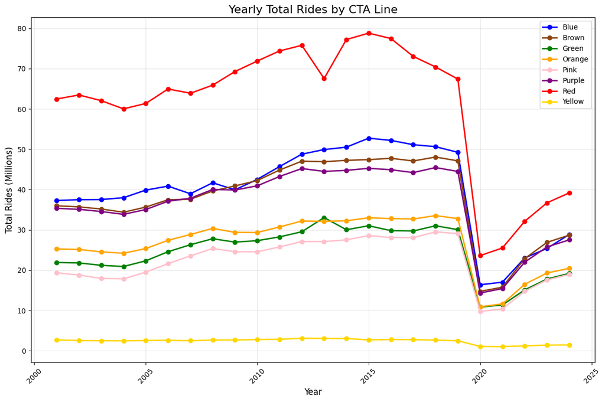

```python
# Define color mapping for each CTA line
colors = {
    'Red': 'red',
    'Blue': 'blue',
    'Brown': 'saddlebrown',
    'Green': 'green',
    'Orange': 'orange',
    'Purple': 'purple',
    'Pink': 'pink',
    'Yellow': 'gold'
}

# Create a line plot showing total rides by year for each line
plt.figure(figsize=(12, 8))

for line in yearly_line_sum.index:
    plt.plot(yearly_line_sum.columns, yearly_line_sum.loc[line]/1000000,
             color=colors[line], label=line, linewidth=2, marker='o')

plt.title('Yearly Total Rides by CTA Line', fontsize=16)
plt.xlabel('Year', fontsize=12)
plt.ylabel('Total Rides (Millions)', fontsize=12)
plt.legend()
plt.grid(True, alpha=0.3)
plt.xticks(rotation=45)
plt.tight_layout()
plt.show()
```

## CAGR Analysis by Line

Calculate and visualize Compound Annual Growth Rates for each line over different time periods.

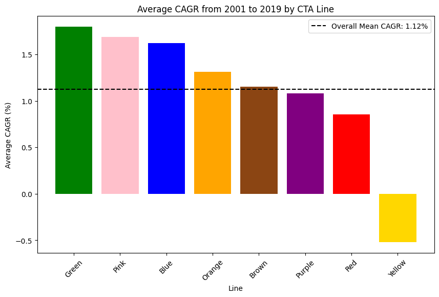

```python
# Calculate CAGR for each line from 2001 to each subsequent year up to 2019
growth_df = yearly_line_sum.copy()
for line in growth_df.index:
    growth_df.loc[line, 2001] = np.nan  # Set base year to NaN
    for year in range(2002, 2020):
        start_val = yearly_line_sum.loc[line, 2001]
        end_val = yearly_line_sum.loc[line, year]
        periods = year - 2001
        cagr = (end_val / start_val) ** (1 / periods) - 1
        growth_df.loc[line, year] = round(cagr * 100, 2)

# Extract CAGR data for 2002-2019
cagr_2001_2019 = growth_df.loc[:, 2002:2019]

# Calculate average CAGR for each line over the period
average_cagr = cagr_2001_2019.mean(axis=1).sort_values(ascending=False)
overall_mean_cagr = average_cagr.mean()

# Plot average CAGR by line
plt.figure(figsize=(10, 6))
plt.bar(average_cagr.index, average_cagr.values, color=[colors[line] for line in average_cagr.index])
plt.axhline(y=overall_mean_cagr, linestyle='--', color='black', label=f'Overall Mean CAGR: {overall_mean_cagr:.2f}%')
plt.title('Average CAGR from 2001 to 2019 by CTA Line')
plt.ylabel('Average CAGR (%)')
plt.xlabel('Line')
plt.xticks(rotation=45)
plt.legend()
plt.show()
```

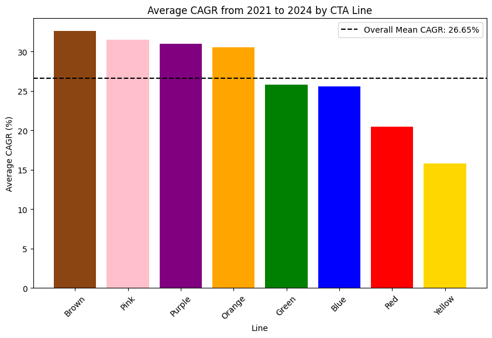

```python
# Calculate CAGR for each line from 2021 to each subsequent year up to 2024
growth_df = yearly_line_sum.copy()
for line in growth_df.index:
    growth_df.loc[line, 2021] = np.nan  # Set base year to NaN
    for year in range(2022, 2025):
        start_val = yearly_line_sum.loc[line, 2021]
        end_val = yearly_line_sum.loc[line, year]
        periods = year - 2021
        cagr = (end_val / start_val) ** (1 / periods) - 1
        growth_df.loc[line, year] = cagr * 100

# Extract CAGR data for 2022-2024
cagr_2021_2024 = growth_df.loc[:, 2022:2024]

# Calculate average CAGR for each line over the period
average_cagr_2021_2024 = cagr_2021_2024.mean(axis=1).sort_values(ascending=False)
overall_mean_cagr_2021_2024 = average_cagr_2021_2024.mean()

# Plot average CAGR by line
plt.figure(figsize=(10, 6))
plt.bar(average_cagr_2021_2024.index, average_cagr_2021_2024.values, color=[colors[line] for line in average_cagr_2021_2024.index])
plt.axhline(y=overall_mean_cagr_2021_2024, linestyle='--', color='black', label=f'Overall Mean CAGR: {overall_mean_cagr_2021_2024:.2f}%')
plt.title('Average CAGR from 2021 to 2024 by CTA Line')
plt.ylabel('Average CAGR (%)')
plt.xlabel('Line')
plt.xticks(rotation=45)
plt.legend()
plt.show()
```